# Prediction of House Prices in Ames

A commented and visual walk-through advanced regression techniques.

Author

Jorge A. Thomas

Published

December 1, 2023

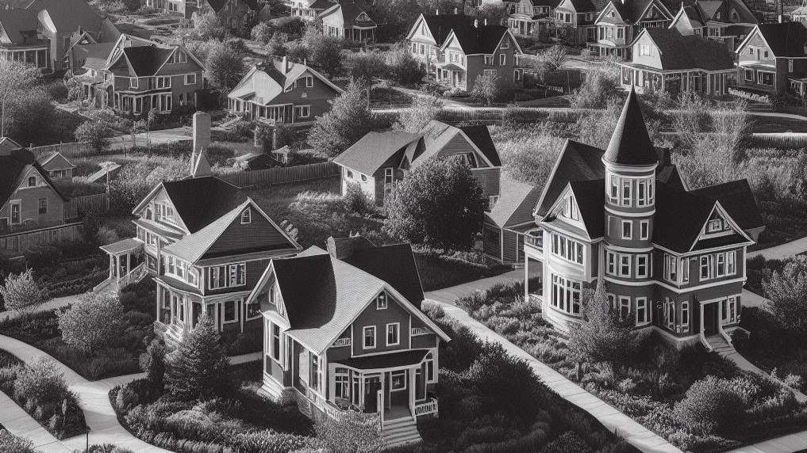

Houses

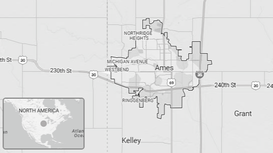

Location

Figure 1: Ames, Iowa - USA.

# Introduction

In this classic Kaggle dataset (Anna Montoya 2016) you’ll follow my workflow developing pipelines on the ETL phase of the DS cycle using the R programming language (R Core Team 2023), as well as a tidy approach on the EDA substantially supported on Visual Analytics. I’ll be feeding some tips on the right margin along the analysis.

The Ames House dataset was prepared to improve on the older classic Boston Houses dataset and, given its open competition nature, it comprises two files:

1. One file contains features and labels or what’s the same predictors and responses. Here this is the *training dataset*. It’s all I have to split the *Data Budget*.
2. Another file contains only features (predictors) to make predictions for the final submissions. Here this is the *test dataset*.

The goal of the competition is to achieve minimum RMSE.

I will keep updating this notebook, making improvements and reporting the rank obtained with my submitted predictions.

# PHASE I: ETL / EDA

## Extract Data

I checked beforehand that there are no missing values, here `NA`, in the target variable `SalePrice`. Therefore, I will write a pipeline to read and concatenate both datasets (bind rows), adding and extra column `dataset` to label as “train” and “test” for further easy splitting[^1] (subset or filter).

<sup>1</sup> The whole Feature Transformation pipeline most be always the same for all predictors in both datasets.

````markdown
```{r}
#| label: Load Data
#| warning: false

ames_train_raw <- read_csv("./data/raw/train.csv") # Train, validattion and test dataset
print("Dimensions of training dataset")
dim(ames_train_raw)

ames_test_raw <- read_csv("./data/raw/test.csv")  # Features for submission dataset
print("Dimensions of test dataset containing only Feats.")
dim(ames_test_raw)

# Add Target column with NA so both DFs can be concatenated:.id
ames_test_raw <-
  ames_test_raw |>
    mutate(SalePrice = NA)

# Binding and adding identifier column "dataset"
ames_all <-
  bind_rows(list(train = ames_train_raw, test = ames_test_raw), .id = "dataset")

print("Available variables:")
names(ames_all)
```
````

```
[1] "Dimensions of training dataset"
[1] 1460   81
[1] "Dimensions of test dataset containing only Feats."
[1] 1459   80
[1] "Available variables:"
 [1] "dataset"       "Id"            "MSSubClass"    "MSZoning"
 [5] "LotFrontage"   "LotArea"       "Street"        "Alley"
 [9] "LotShape"      "LandContour"   "Utilities"     "LotConfig"
[13] "LandSlope"     "Neighborhood"  "Condition1"    "Condition2"
[17] "BldgType"      "HouseStyle"    "OverallQual"   "OverallCond"
[21] "YearBuilt"     "YearRemodAdd"  "RoofStyle"     "RoofMatl"
[25] "Exterior1st"   "Exterior2nd"   "MasVnrType"    "MasVnrArea"
[29] "ExterQual"     "ExterCond"     "Foundation"    "BsmtQual"
[33] "BsmtCond"      "BsmtExposure"  "BsmtFinType1"  "BsmtFinSF1"
[37] "BsmtFinType2"  "BsmtFinSF2"    "BsmtUnfSF"     "TotalBsmtSF"
[41] "Heating"       "HeatingQC"     "CentralAir"    "Electrical"
[45] "1stFlrSF"      "2ndFlrSF"      "LowQualFinSF"  "GrLivArea"
[49] "BsmtFullBath"  "BsmtHalfBath"  "FullBath"      "HalfBath"
[53] "BedroomAbvGr"  "KitchenAbvGr"  "KitchenQual"   "TotRmsAbvGrd"
[57] "Functional"    "Fireplaces"    "FireplaceQu"   "GarageType"
[61] "GarageYrBlt"   "GarageFinish"  "GarageCars"    "GarageArea"
[65] "GarageQual"    "GarageCond"    "PavedDrive"    "WoodDeckSF"
[69] "OpenPorchSF"   "EnclosedPorch" "3SsnPorch"     "ScreenPorch"
[73] "PoolArea"      "PoolQC"        "Fence"         "MiscFeature"
[77] "MiscVal"       "MoSold"        "YrSold"        "SaleType"
[81] "SaleCondition" "SalePrice"
```

## Impute Missing Values

First things first, read the full [data description](https://www.kaggle.com/competitions/house-prices-advanced-regression-techniques/data)[^2]. There you’ll find that for several columns, missing values `NA` means actually *“None”*. The physical absence of a determined feature in a house is a category exposing the lack of such quality that can have a significant impact on the response `SalePrice`. Later it is most probably that binary features indicating the existence of some installations should be created.

<sup>2</sup> **Print a copy**, make notes and study it. This is the first step to get into domain knowledge, in this case Real Estate, for later *Feature Engineering*.

Therefore, I will fill the empty `NA` fields of the indicated columns of both datasets with the string *“None”*.

````markdown
```{r}
#| label: easy replace_na

cols_NA_to_none <- list(
  Alley = "None",
  BsmtQual = "None", BsmtCond = "None", BsmtExposure = "None", BsmtFinType1 = "None", BsmtFinType2 = "None",
  FireplaceQu = "None",
  GarageType = "None", GarageFinish = "None", GarageQual = "None", GarageCond = "None",
  PoolQC = "None",
  Fence = "None",
  MiscFeature = "None")

ames_all <- ames_all |>
  replace_na(cols_NA_to_none)
```
````

One of the early and recurrent steps of the EDA is to check the **completeness of data**. Let’s search for missing values, after filling indicated fields[^3]. For this case I wrote the function `count_na()` that generates the table displayed on the right margin.

<sup>3</sup> **Write a function to quantify missing values** depending on the language and labelling system used.

````markdown
```{r}
#| label: Counting NAs
#| code-fold: false
#| column: margin

# Remaining NA count leaving out target SalePrice
ames_all |>
  select(-SalePrice) |>
  count_na() |>
  knitr::kable(caption = 'Ames dataset')
```
````

Ames dataset

| Variable | NA_count | Percent |
| --- | --- | --- |
| LotFrontage | 486 | 16.65 |
| GarageYrBlt | 159 | 5.45 |
| MasVnrType | 24 | 0.82 |
| MasVnrArea | 23 | 0.79 |
| MSZoning | 4 | 0.14 |
| Utilities | 2 | 0.07 |
| BsmtFullBath | 2 | 0.07 |
| BsmtHalfBath | 2 | 0.07 |
| Functional | 2 | 0.07 |
| Exterior1st | 1 | 0.03 |
| Exterior2nd | 1 | 0.03 |
| BsmtFinSF1 | 1 | 0.03 |
| BsmtFinSF2 | 1 | 0.03 |
| BsmtUnfSF | 1 | 0.03 |
| TotalBsmtSF | 1 | 0.03 |
| Electrical | 1 | 0.03 |
| KitchenQual | 1 | 0.03 |
| GarageCars | 1 | 0.03 |
| GarageArea | 1 | 0.03 |
| SaleType | 1 | 0.03 |

I’ll fill the remaining missing values as follow:

- The `LotFrontage` column refers to the linear feet of street connected to the house. This feature is not well documented and the missing percentage related to other variables makes it not only unreliable, but very low in variance. Therefore, I will delete the feature.
- Everytime a Garage doesn’t exist, i.e., `GarageType = "None"`, there is the corresponding missing value in Garage Year Built `GarageYrBlt = NA`. I will **engineer a new feature** called `GarageNew` with three ordinal categories: None, No, Yes. This based on the delta of `YearBuilt - GarageYrBlt`; I expect that given the house price, the algorithm will learn that “None” is worse than “No” and so on. Then I will remove the `GarageYrBlt` predictor.
- For the rest of variables with a 1 % or less missing values `NA`, I’ll calculate the **median** (if numerical) and the **mode** (if string) in order to fill them with it.

Here’s my pipeline for the whole dataset:

````markdown
```{r}
#| label: terminating NAs

# "replace_na_with_median" is a function I created

ames_all <- ames_all |>
  mutate(LotFrontage = NULL) |> # Removing LotFrontage
  mutate(GarageNew = if_else(YearBuilt - GarageYrBlt > 0, "Yes", "No")) |> # New Feat.
  replace_na(list(GarageNew = "None")) |>
  mutate(GarageNew = factor(GarageNew, levels = c("None", "No", "Yes"), ordered = TRUE)) |> # 3 levels
  mutate(GarageYrBlt = NULL) |> # Removing old Feat.
  mutate_if(is.numeric, replace_na_with_median)
```
````

Let’s get a list with the mode of each remaining columns containing missing values `NA`.

````markdown
```{r}
#| label: Mode for NAs

# Get the mode for reamaining columns with NAs:
# "find_mode()" is a custom function.

# Good, old-fashioned code: apply(ames_all, 2, find_mode)

list_na_mode <- ames_all |>
  select(MasVnrType, MasVnrArea, MSZoning, Electrical, Utilities,   BsmtFullBath,   BsmtHalfBath,   Functional, Exterior1st,    Exterior2nd,    BsmtFinSF1, BsmtFinSF2, BsmtUnfSF,  TotalBsmtSF,    KitchenQual,GarageCars, GarageArea, SaleType) |>
  map(find_mode)

# map returns a list

# Replace with the created named-lists
ames_all <- ames_all |>
  replace_na(list_na_mode)

# Sanity check of missing values:
print("Full Ames dataset (train and test)")
ames_all |>
  select(-SalePrice) |>
  count_na()
```
````

```
[1] "Full Ames dataset (train and test)"
[1] "No missing values (NA) found."
```

**“The data is complete!”** Let’s think about predictors.

There are variables (columns) starting with numbers? I’ll rename them:

````markdown
```{r}
#| label: rename_cols

ames_all <-
  ames_all |>
  rename(FirstFlrSF = "1stFlrSF") |>
  rename(SecondFlrSF = "2ndFlrSF") |>
  rename(threessnporch = "3SsnPorch")
```
````

### Screening of variable importance

Using the **Mutual Information criterion (MI)**, I’ll rank the extent to which knowledge of each original predictor reduces the uncertainty of `SalePrice`.

````markdown
```{r}
#| label: mutual-info
#| column: margin
#| code-fold: false

library(infotheo)

# "calc_mi" is a function I wrote.

mi_y_X <- ames_all |>
  filter(dataset == "train") |>
  select(-c(Id, dataset)) |>
  calc_mi_score(target = "SalePrice")

mi_y_X |>
  head(20) |>
  knitr::kable(caption = "Mutual Info")
```
````

Mutual Info

|  | Variable | nats | Percent |
| --- | --- | --- | --- |
| SalePrice | SalePrice | 2.6515433 | 100.0000 |
| OverallQual | OverallQual | 0.6086855 | 22.9559 |
| Neighborhood | Neighborhood | 0.6084916 | 22.9486 |
| GrLivArea | GrLivArea | 0.5723431 | 21.5853 |
| GarageArea | GarageArea | 0.5244219 | 19.7780 |
| YearBuilt | YearBuilt | 0.5195234 | 19.5932 |
| YearRemodAdd | YearRemodAdd | 0.4564483 | 17.2144 |
| TotalBsmtSF | TotalBsmtSF | 0.4473484 | 16.8712 |
| FirstFlrSF | FirstFlrSF | 0.4141527 | 15.6193 |
| GarageCars | GarageCars | 0.3805914 | 14.3536 |
| SecondFlrSF | SecondFlrSF | 0.3735544 | 14.0882 |
| BsmtUnfSF | BsmtUnfSF | 0.3544288 | 13.3669 |
| MSSubClass | MSSubClass | 0.3458352 | 13.0428 |
| BsmtQual | BsmtQual | 0.3425788 | 12.9200 |
| ExterQual | ExterQual | 0.3394960 | 12.8037 |
| KitchenQual | KitchenQual | 0.3283328 | 12.3827 |
| OpenPorchSF | OpenPorchSF | 0.3051952 | 11.5101 |
| FullBath | FullBath | 0.2863069 | 10.7977 |
| GarageFinish | GarageFinish | 0.2784786 | 10.5025 |
| WoodDeckSF | WoodDeckSF | 0.2706731 | 10.2081 |

## Feature Engineering

I have already started with the creation of a new predictor in the previous step, this to substitute the problematic variable `GarageYrBlt` that had a lot of missing values.

Feature creation and transformations are not sequential, i.e., this is not the only step where *Feature Engineering* is applied. Think about the next *modelling phase*, where you want to reduce features, e.g., where new Principal Components are the new aggregators of original features.

In this part I will establish which variables are categorical and numerical; this is not always as obvious as it seems[^4].

<sup>4</sup> Integer variables like calendar *Years* can be treated as categories for the analysis.

The first easy thing that comes to mind is to add the **total area of the property** as a new column named `TotAreaSF`; SF means *Squared Feet*.

After that, I check the [data documentation](https://www.kaggle.com/competitions/house-prices-advanced-regression-techniques/data) to see which variables can be thought as factors; this can be tedious if Real Estate is not your domain of expertise.

After 1.5 hours of reading, googling, understanding other notebooks and deliberating (yes, it was tedious), I can summarise four types of ways to engineer new features depending on the nature of the variables:

1. Aggregation to a total of **continuous-numerical** surface area (Square Feet), e.g. new `TotalIntArea` Feat. summing basement and floors, etc. Same for a new `TotalExtArea`. Then deleting the addends variables.
2. Aggregation to a total of **counts-numerical** of an available installation of a determined type, e.g. new `TotBaths`. Then deleting the addends.
3. Categorisation with ascending quality levels of the originally numerical variables `OverallQual` and `OverallCond`.
4. Creation of new **binary** features that state if a determined installation exists or doesn’t.

After my second Kaggle submission (Top 25%) I completed the [Feature Engineering course](https://www.kaggle.com/learn/feature-engineering) that has a lot of tips! I included some new features and tricks from there.

Here’s the code that complies with the four previous steps:

````markdown
```{r}
#| label: Feat-Eng

# --- Total Aggregations ----
ames_all <- ames_all |>

  # Continuous numerical ----
  # NEW TotalInteriorArea
  mutate(TotalIntArea = BsmtFinSF1 + BsmtFinSF2 + FirstFlrSF + SecondFlrSF) |>

  # NEW Interior Areas to lengths (sqrt Feat. Transformation)
  # mutate(TotalIntLength = sqrt(TotalIntArea)) |>
  # mutate(BsmtFinF1 = sqrt(BsmtFinSF1)) |>
  # mutate(BsmtFinF2 = sqrt(BsmtFinSF2)) |>
  # mutate(FirstFlrF = sqrt(FirstFlrSF)) |>
  # mutate(SecondFlrF = sqrt(SecondFlrSF)) |>

  select(-c(BsmtFinSF1, BsmtFinSF2)) |> # Bye bye...

  # NEW TotalExteriorArea
  mutate(TotalExtArea = WoodDeckSF + OpenPorchSF + EnclosedPorch + threessnporch + ScreenPorch + GarageArea) |>
  select(-c(WoodDeckSF, OpenPorchSF, EnclosedPorch, threessnporch, ScreenPorch)) |> # Bye bye...

  # NEW Exterior Areas to lengths (sqrt Feat. Transformation)
  # mutate(TotalExtLength = sqrt(TotalExtArea)) |>

  # NEW GarageLength
  # mutate(GarageLength = sqrt(GarageArea)) |>

  # Counting numerical ----
  # NEW TotalBaths
  mutate(TotBaths = BsmtFullBath + 0.5 * BsmtHalfBath + FullBath + 0.5 * HalfBath) |>
  select(-c(BsmtFullBath, BsmtHalfBath, FullBath, HalfBath)) # Bye bye...


# ---- Ordered Categorical Features ----

# Check which columns have "None"
# sapply(ames_all, function(x) sum(x == "None"))

ames_all <- ames_all |>
  # 10 Levels:
  mutate(OverallQual = factor(OverallQual, seq(1, 10), ordered = TRUE)) |>
  mutate(OverallCond = factor(OverallCond, seq(1, 10), ordered = TRUE)) |>

  # 5 Levels + None
  mutate(ExterQual = factor(ExterQual, c("Po", "Fa", "TA", "Gd", "Ex"), ordered = TRUE)) |>
  mutate(ExterCond = factor(ExterCond, c("Po", "Fa", "TA", "Gd", "Ex"), ordered = TRUE)) |>
  mutate(BsmtQual = factor(BsmtQual, c("None", "Po", "Fa", "TA", "Gd", "Ex"), ordered = TRUE)) |>
  mutate(BsmtCond = factor(BsmtCond, c("None", "Po", "Fa", "TA", "Gd", "Ex"), ordered = TRUE)) |>
  mutate(HeatingQC = factor(HeatingQC, c("Po", "Fa", "TA", "Gd", "Ex"), ordered = TRUE)) |>
  mutate(KitchenQual = factor(KitchenQual, c("Po", "Fa", "TA", "Gd", "Ex"), ordered = TRUE)) |>
  mutate(FireplaceQu = factor(FireplaceQu, c("None", "Po", "Fa", "TA", "Gd", "Ex"), ordered = TRUE)) |>
  mutate(GarageQual = factor(GarageQual, c("None", "Po", "Fa", "TA", "Gd", "Ex"), ordered = TRUE)) |>
  mutate(GarageCond = factor(GarageCond, c("None", "Po", "Fa", "TA", "Gd", "Ex"), ordered = TRUE)) |>
  mutate(PoolQC = factor(PoolQC, c("None", "Po", "Fa", "TA", "Gd", "Ex"), ordered = TRUE)) |>

  #  Others:
  mutate(LotShape = factor(LotShape, c("Reg", "IR1", "IR2", "IR3"), ordered = TRUE)) |>
  mutate(LandSlope = factor(LandSlope, c("Sev", "Mod", "Gtl"), ordered = TRUE)) |>
  mutate(BsmtExposure = factor(BsmtExposure, c("None", "No", "Mn", "Av", "Gd"), ordered = TRUE)) |>
  mutate(BsmtFinType1 = factor(BsmtFinType1, c("None", "Unf", "LwQ", "Rec", "BLQ", "ALQ", "GLQ"), ordered = TRUE)) |>
  mutate(BsmtFinType2 = factor(BsmtFinType2, c("None", "Unf", "LwQ", "Rec", "BLQ", "ALQ", "GLQ"), ordered = TRUE)) |>
  mutate(Functional = factor(Functional, c("Sal", "Sev", "Maj1", "Maj2", "Mod", "Min2", "Min1", "Typ"), ordered = TRUE)) |>
  mutate(GarageFinish = factor(GarageFinish, c("None", "Unf", "RFn", "Fin"), ordered = TRUE)) |>
  mutate(PavedDrive = factor(PavedDrive, c("N", "P", "Y"), ordered = TRUE)) |>
  mutate(Utilities = factor(Utilities, c("NoSeWa", "NoSewr", "AllPub"), ordered = TRUE)) |>
  mutate(Electrical = factor(Electrical, c("Mix", "FuseP", "FuseF", "FuseA", "SBrkr"), ordered = TRUE)) |>
  mutate(Fence = factor(Fence, c("None", "MnWw", "GdWo", "MnPrv", "GdPrv"), ordered = TRUE))


# ---- New Binary Features ----

# Does the installation or Feature exist?
ames_all <- ames_all |>
  # CentralAir
  mutate(CentralAir = if_else(CentralAir == "N", "No", "Yes")) |>
  mutate(CentralAir = fct_relevel(CentralAir, "No", "Yes"))|>

  # NEW IsRemodelled (it will replace YearRemodAdd)
  # mutate(IsRemodelled = if_else(YearRemodAdd - YearBuilt > 0, "Yes", "No")) |>
  # mutate(IsRemodelled = factor(IsRemodelled, levels = c("No", "Yes"))) |>
  # select(-YearRemodAdd) |> # Bye YearRemodAdd
  # Not important

  # NEW ExistPool
  mutate(ExistPool = if_else(PoolArea == 0, "No", "Yes")) |>
  mutate(ExistPool = fct_relevel(ExistPool, "No", "Yes"))|>
  # a dummy of PoolQC makes this Feat. Redundant, BUT PoolQC has no Information! (Eliminated)

  # NEW ExistGarage
  mutate(ExistGarage = if_else(GarageArea == 0, "No", "Yes")) |>
  mutate(ExistGarage = fct_relevel(ExistGarage, "No", "Yes"))|>
  select(-c(GarageArea)) |> # Bye

  # NEW ExistBsmt
  mutate(ExistBsmt = if_else(TotalBsmtSF == 0, "No", "Yes")) |>
  mutate(ExistBsmt = fct_relevel(ExistBsmt, "No", "Yes"))|>

  # NEW Exist2ndFloor
  mutate(Exist2ndFloor = if_else(`SecondFlrSF` == 0, "No", "Yes")) |>
  mutate(Exist2ndFloor = fct_relevel(Exist2ndFloor, "No", "Yes")) |>

  # NEW ExistFireplace
  mutate(ExistFireplace = if_else(Fireplaces == 0, "No", "Yes")) |>
  mutate(ExistFireplace = fct_relevel(ExistFireplace, "No", "Yes")) |>

  # NEW ExistMasVeneer: Masonry veneer area
  mutate(ExistMasVeneer = if_else(MasVnrArea > 0, "Yes", "No")) |>
  mutate(ExistMasVeneer = factor(ExistMasVeneer, levels = c("No", "Yes"))) |>

  # From Kaggle's Feature Engineering course ----

  # New ratios
  mutate(LivLotRatio = GrLivArea/LotArea) |>
  mutate(Spaciousness = (FirstFlrSF + SecondFlrSF) / TotRmsAbvGrd) |>
  # select(-c(FirstFlrSF)) |>

  # New interactions (by me!)
  mutate(OverallQuCoInt = as.numeric(OverallQual) * as.numeric(OverallCond))



# ---- Unordered factors ----

# Nominative (unordered) categorical Feats
cats_feats <- c("MSSubClass", "MSZoning", "Street", "Alley", "LandContour", "LotConfig",
                "Neighborhood", "Condition1", "Condition2", "BldgType", "HouseStyle",
                "RoofStyle", "RoofMatl", "Exterior1st", "Exterior2nd", "MasVnrType",
                "Foundation", "Heating", "CentralAir", "GarageType", "MiscFeature",
                "SaleType", "SaleCondition")

ames_all <- ames_all |>
  #mutate(across(where(is.character), factor)) |>
  mutate(across(all_of(cats_feats), ~ factor(.x, ordered = FALSE)))


# ---- Numerical Features ----

# BedroomabvGr (count) left numerical
# Kitchens (count) left numerical
# TotRmsAbvGrd (count) left numerical
# Fireplaces (count) left numerical
# GarageCars (count) left numerical
# GarageArea (continous) left numerical
# MiscVal left numerical
# MasVnrArea (continous) left numeric


# ---- Remove 'LowQualFinSF' ----

# Low quality finished square feet (all floors)
# Most of the values are 0 -> almost 0 variance.

ames_all$LowQualFinSF <- NULL
ames_all$PoolArea <- NULL
```
````

Column `MSSubClass` has too many categories, therefore I will perform **target enconding** in the *recipe* as a step.

### Recheck mutual info

````markdown
```{r}
#| label: recheck_mi
#| column: margin

# "calc_mi_score" is a function I wrote.

mi_y_X_2 <- ames_all |>
  filter(dataset == "train") |>
  select(-c(Id, dataset)) |>
  calc_mi_score(target = "SalePrice")

mi_y_X_2 |>
  head(20) |>
  knitr::kable(caption = "Mutual Information")
```
````

Mutual Information

|  | Variable | nats | Percent |
| --- | --- | --- | --- |
| SalePrice | SalePrice | 2.6515433 | 100.0000 |
| OverallQual | OverallQual | 0.6086855 | 22.9559 |
| Neighborhood | Neighborhood | 0.6084916 | 22.9486 |
| GrLivArea | GrLivArea | 0.5723431 | 21.5853 |
| TotalExtArea | TotalExtArea | 0.5331534 | 20.1073 |
| TotalIntArea | TotalIntArea | 0.5243177 | 19.7741 |
| YearBuilt | YearBuilt | 0.5195234 | 19.5932 |
| OverallQuCoInt | OverallQuCoInt | 0.4865985 | 18.3515 |
| YearRemodAdd | YearRemodAdd | 0.4564483 | 17.2144 |
| TotalBsmtSF | TotalBsmtSF | 0.4473484 | 16.8712 |
| FirstFlrSF | FirstFlrSF | 0.4141527 | 15.6193 |
| Spaciousness | Spaciousness | 0.4133356 | 15.5885 |
| TotBaths | TotBaths | 0.4108588 | 15.4951 |
| GarageCars | GarageCars | 0.3805914 | 14.3536 |
| SecondFlrSF | SecondFlrSF | 0.3735544 | 14.0882 |
| BsmtUnfSF | BsmtUnfSF | 0.3544288 | 13.3669 |
| MSSubClass | MSSubClass | 0.3458352 | 13.0428 |
| BsmtQual | BsmtQual | 0.3425788 | 12.9200 |
| ExterQual | ExterQual | 0.3394960 | 12.8037 |
| KitchenQual | KitchenQual | 0.3283328 | 12.3827 |

#### Drop no info columns

````markdown
```{r}
#| label: noinfo_drop
#| code-fold: false

# < 0.06444 == < 2.4%

noinfo_cols <- mi_y_X_2$Variable[which(mi_y_X_2$Percent < 2.4)]

ames_all <-
  ames_all |>
  select(-all_of(noinfo_cols))
```
````

### Searching for simple correlations

Although **nothing is linear**, is good to have an idea of simple correlations between all variables; it gives me an idea of what kind of plots to make. After going through the previous steps, it’s obvious that there are correlations. Think about the number of cars that fit in a garage `GarageCars` and the area of the garage `GarageArea`.

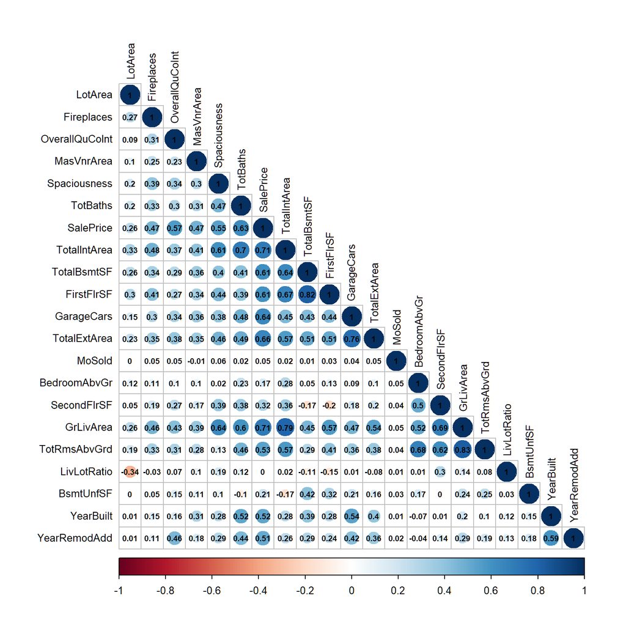

Figure 2: The Pearson’s correlation of numeric features and response shows high presence of multicollinearity.

````markdown
```{r}
#| label: fig-num-corr
#| fig-width: 8
#| fig-height: 8
#| fig-cap: The Pearson's correlation of numeric features and response shows high presence of multicollinearity.
#| warning: false
#| message: false

library(corrplot)

ames_all |>
  filter(dataset == "train") |>
  select(-c(dataset, Id)) |>
  select(where(is.numeric)) |>
  cor(method = "pearson") |>
  corrplot(type = "lower", method = "circle", insig = 'blank', order = "hclust", diag = TRUE,
  tl.col="black", tl.cex = 0.8, addCoef.col = 'black', number.cex = 0.6)
```
````

I’m leaving blank, i.e., without a circle, the insignificant correlations for better visualisation and focus. Now I’m checking the categorical variables and the response.

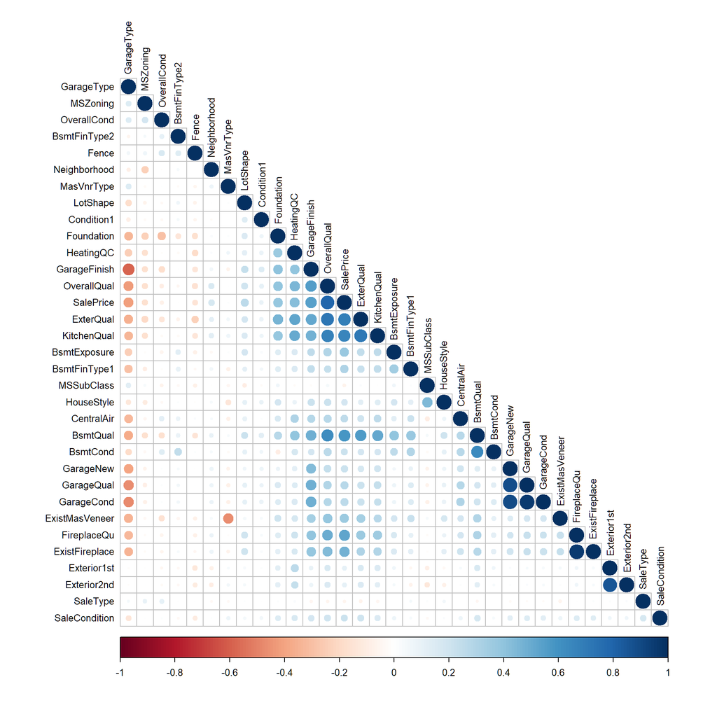

Figure 3: Pearson’s correlation of categorical features and response.

````markdown
```{r}
#| label: fig-cat-corr
#| fig-width: 10
#| fig-height: 10
#| fig-cap: Pearson's correlation of categorical features and response.
#| warning: false
#| message: false

ames_all |>
  filter(dataset == "train") |>
  select(-dataset) |>
  select(where(is.factor) | contains("Price")) |>
  mutate_if(is.factor, as.integer) |>
  cor(method = "pearson") |>
  corrplot(type = "lower", order="hclust", diag = TRUE, insig = 'blank',
  tl.col="black", tl.cex = 0.8, number.cex = 0.6)
```
````

The best linear association with `SalePrice` is given by `OverallQual` factor, followed by everything else that has to do with *quality* ratings.

Overall, one can see clearly the **multicollinearity** clusters, which suggest the use of advanced **Feature Selection** techniques.

### Visual Exploration

Now with the previous information in hand, I’m going to visualise separately the two most important quasi-linear relationships: `GrLivArea` and `OverallQual` vs. `SalePrice`.

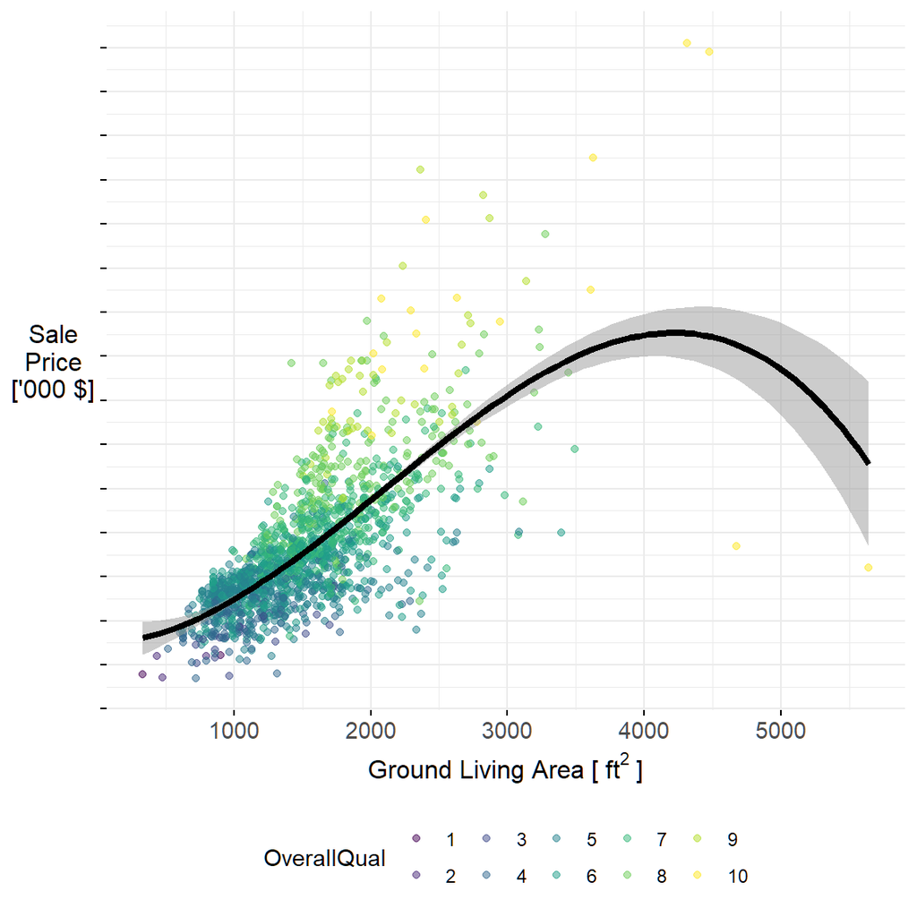

(a) Scatter Plot

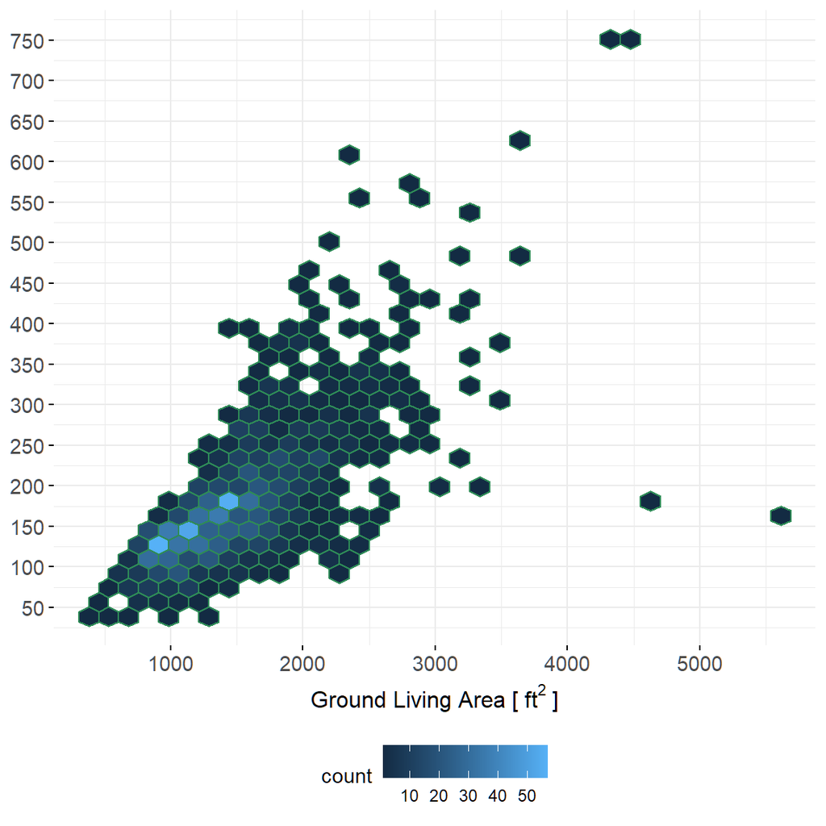

(b) Hexbin Plot

Figure 4: GrvLivArea Vs. SalePrice - The most “linear” realationship between continuous variables. One can clearly notice the increase of variance as both, Living Area and Price increase, i.e., heteroskedasticity.

````markdown
```{r}
#| label: fig-cont_linear
#| message: false
#| warning: false
#| column: body
#| fig-width: 6
#| fig-height: 6
#| fig-cap: 'GrvLivArea Vs. SalePrice - The most "linear" realationship between continuous variables. One can clearly notice the increase of variance as both, Living Area and Price increase, i.e., heteroskedasticity.'
#| cap-location: margin
#| fig-subcap:
#|   - "Scatter Plot"
#|   - "Hexbin Plot"
#| layout-ncol: 2

ames_all |>
  filter(dataset == "train") |>
  ggplot(aes(x = GrLivArea, y = SalePrice/1000)) +
  scale_y_continuous(breaks = seq(0, 800, 50), labels = scales::comma) +
  labs(x = expression("Ground Living Area ["~ft^2~"]"),
       y = "Sale\nPrice\n['000 $]") +
  geom_point(aes(color = OverallQual), alpha = 0.5) + theme(axis.text.y = element_blank()) +
  geom_smooth(method = "lm", formula =  y ~ splines::bs(x, 3), color = "black", linewidth = 1.5, alpha = 0.5) +
  theme(legend.position = "bottom")

# install.packages("hexbin")
ames_all |>
  filter(dataset == "train") |>
  ggplot(aes(x = GrLivArea, y = SalePrice/1000)) +
  scale_y_continuous(breaks = seq(0, 800, 50), labels = scales::comma) +
  geom_hex(bins = 35, colour = "seagreen") +
  labs(x = expression("Ground Living Area ["~ft^2~"]")) +
  theme(axis.title.y = element_blank(), legend.position = "bottom")
```
````

The hexbin plot reveals three cells of price and size where houses are more common in the training dataset. **There are more than 50 houses for each bin in the range of 130K, 140K and 180K USD** approximately.

On the other hand, note how **problematic are the outliers** with the spline fit! This visual allows me to *remove outliers*, i.e., the biggest and cheap houses (right data points).

```
Rows: 2
Columns: 3
$ SalePrice   <dbl> 184750, 160000
$ GrLivArea   <dbl> 4676, 5642
$ OverallQual <ord> 10, 10
```

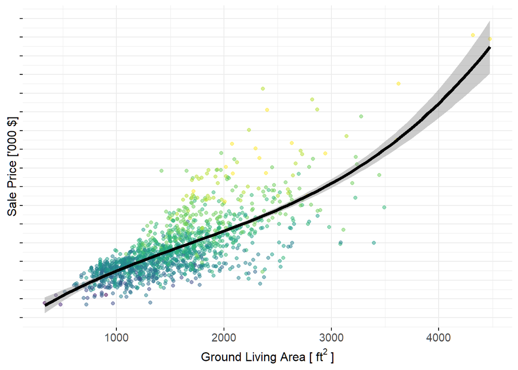

Figure 5: Removing two outliers from the training dataset part the spline fit is dramatically improved!

````markdown
```{r}
#| label: fig-RemoveOutliers
#| fig-cap: Removing two outliers from the training dataset part the spline fit is dramatically improved!
#| column: margin

ames_all |>
  filter(dataset == "train") |>
  select(c(SalePrice, GrLivArea, OverallQual)) |>
  filter(GrLivArea > 4500) |>
  glimpse()

idx_remove <- which(ames_all$dataset == "train" & ames_all$GrLivArea > 4500)

ames_all <-
  ames_all |>
    filter(!row_number() %in% idx_remove)

ames_all |>
  filter(dataset == "train") |>
  ggplot(aes(x = GrLivArea, y = SalePrice/1000)) +
  scale_y_continuous(breaks = seq(0, 800, 50), labels = scales::comma) +
  labs(x = expression("Ground Living Area ["~ft^2~"]"),
       y = "Sale Price ['000 $]") +
  geom_point(aes(color = OverallQual), alpha = 0.5) + theme(axis.text.y = element_blank()) +
  geom_smooth(method = "lm",
              formula =  y ~ splines::bs(x, 3),
              color = "black",
              size = 1.5,
              alpha = 0.5) +
  theme(legend.position = "none", axis.title.y = element_text(angle = 90))
```
````

The **two big houses above were super offers!** Or did the housing bubble exploded?

In the same fashion, I want to see the effect of the factor `OverallQual`.

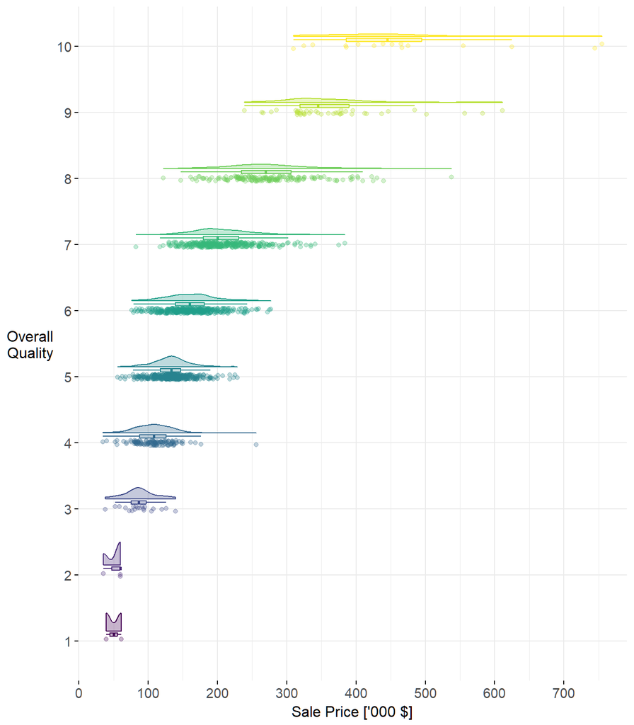

Figure 6: OverallQual Vs. SalePrice - The most “linear” realationship with a categorical predictor. The raincloud plot shows how variances of factors are very different.

````markdown
```{r}
#| label: fig-cat_linear
#| message: false
#| warning: false
#| fig-width: 7
#| fig-height: 8
#| fig-cap: 'OverallQual Vs. SalePrice - The most "linear" realationship with a categorical predictor. The raincloud plot shows how variances of factors are very different.'

# install.packages("ggrain")
library(ggrain)

ames_all |>
  filter(dataset == "train") |>
  ggplot(aes(x = OverallQual, y = SalePrice/1000, colour = OverallQual, fill = OverallQual)) +
  geom_rain(alpha = 0.3) +
  scale_y_continuous(breaks = seq(0, 800, 100)) +
  labs(x = "Overall\nQuality", y = "Sale Price ['000 $]") +
  coord_flip() +
  theme(legend.position = "none")
```
````

#### I’m wondering in which price range is the most popular quality?

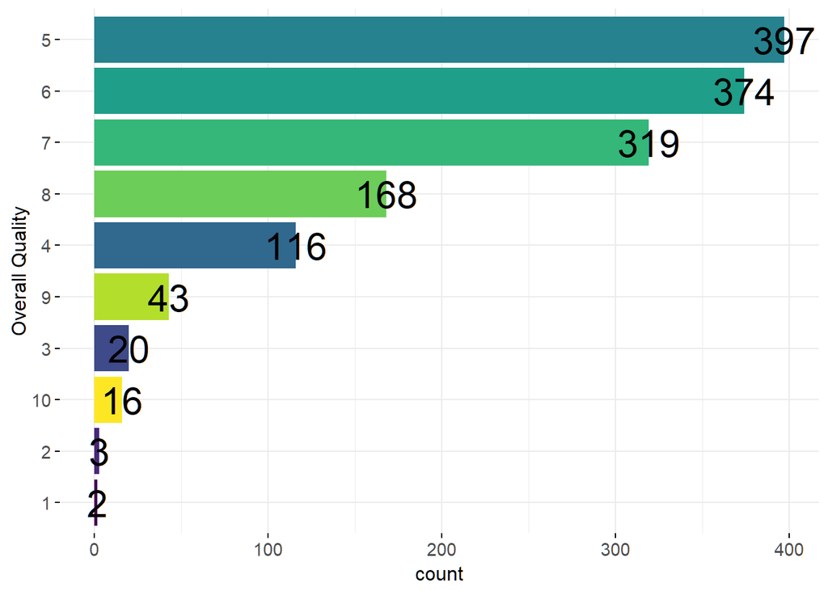

Figure 7: Houses with mid-quality levels are most frequent in the train dataset.

````markdown
```{r}
#| label: fig-count_overallQual
#| cap-location: margin
#| fig-cap: "Houses with mid-quality levels are most frequent in the train dataset."
#| column: margin
#| code-fold: false

ames_all |>
  filter(dataset == "train") |>
  count(OverallQual, name = "count") |>
  ggplot(aes(y = fct_reorder(OverallQual, count), x = count)) +
  geom_col(aes(fill = OverallQual)) +
  geom_text(aes(label = count), size = 8) +
  labs(y = "Overall Quality") +
  theme(legend.position = "none", axis.title.y = element_text(angle = 90))
```
````

It seems that most popular houses, with an overall quality of 5 (mid-quality level), are the ones between 120K and 145K USD. Of course, this was back in the years of 2006 - 2010.

#### How sale prices vary with the living area and depending on house styles?

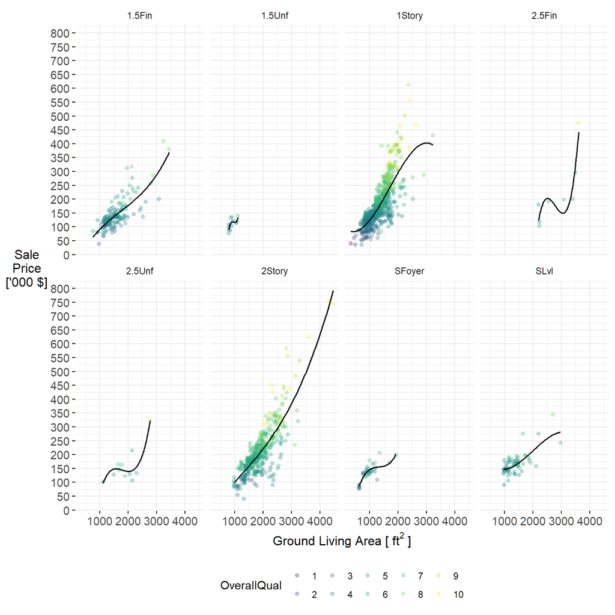

Figure 8: One and two story houses are the most common within the train dataset.

````markdown
```{r}
#| label: fig-houseStyles
#| fig-column: page-right
#| fig-width: 8
#| fig-height: 8
#| fig-cap: "One and two story houses are the most common within the train dataset."

ames_all |>
  filter(dataset == "train") |>
  ggplot(aes(x = GrLivArea, y = SalePrice/1000)) +
  scale_y_continuous(breaks = seq(0, 800, 50), labels = scales::comma) +
  labs(x = expression("Ground Living Area ["~ft^2~"]"),
       y = "Sale\nPrice\n['000 $]") +
  geom_point(aes(color = OverallQual), alpha = 0.3) +
  geom_smooth(method = "lm",
              formula =  y ~ splines::bs(x, 3),
              color = "black",
              se = FALSE,
              size = 0.7,
              alpha = 0.5) +
  facet_wrap(~HouseStyle, nrow = 2) +
  theme(legend.position = "bottom")
```
````